# **OFE Equity Dashboard**

**Demographics for clients served and surveyed: Jan-Jun 2021 v. Jan-Jun 2022**

**TOTAL  SERVED**

#### Financial Empowerment Centers

**Number of clients served with at least one financial counseling session of no fewer than 30 minutes**  
2022: 3,521  
2021: 3,244

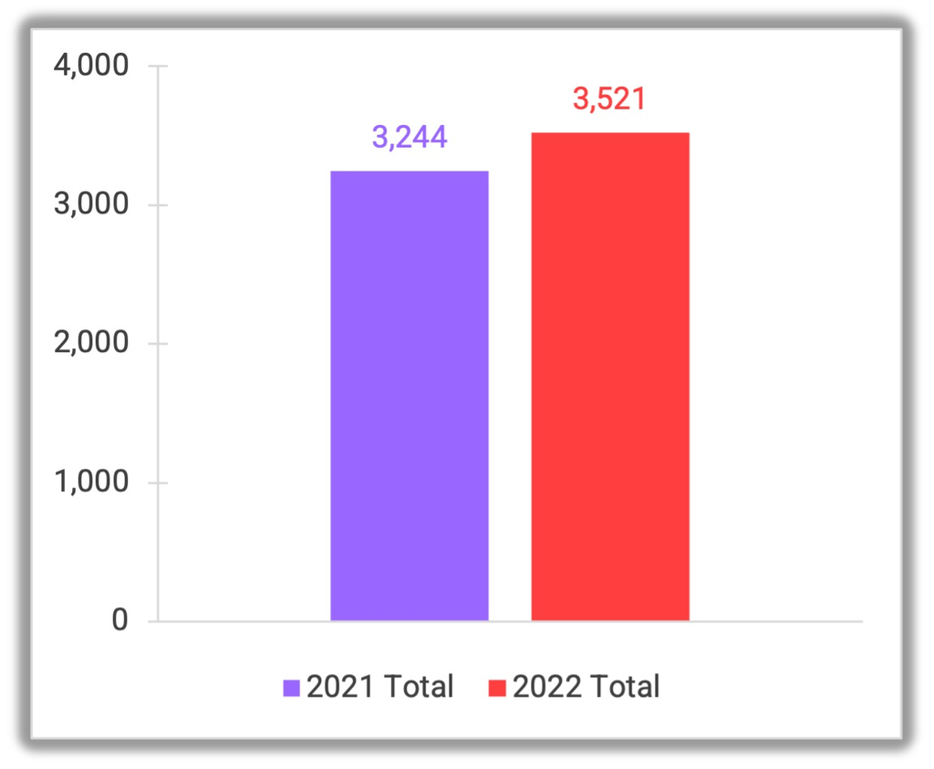

#### Free Tax Prep

**Number of unique filers served by contracted nonprofits**  
2022: 39,453  
2021: 29,501

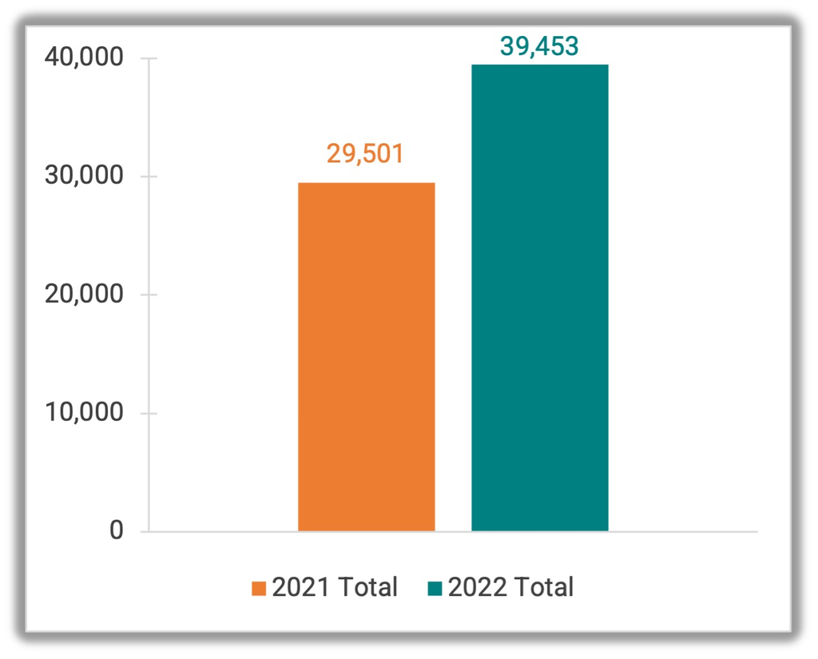

**RACE**

#### Financial Empowerment Centers

**Number of clients served with at least one financial counseling session of no fewer than 30 minutes**  
2022: 3,521  
2021: 3,244

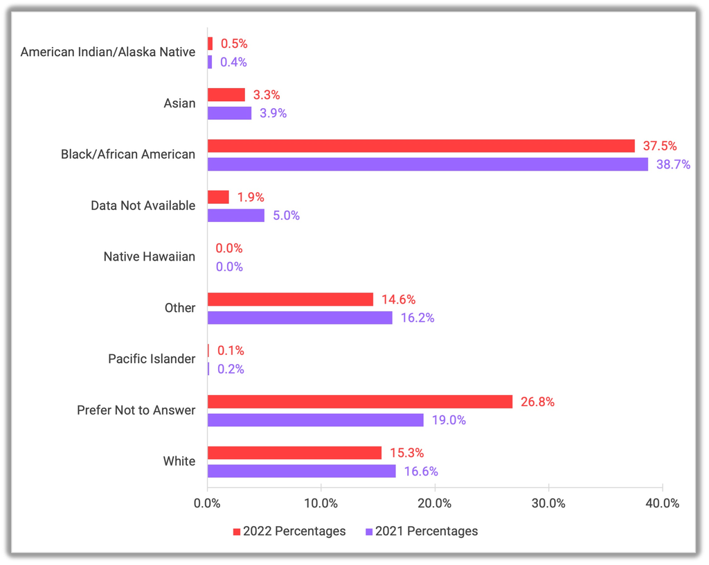

#### Free Tax Prep

**Data among filers served by contracted nonprofits who responded to survey**  
2022: 29,187  
2021: 20,606

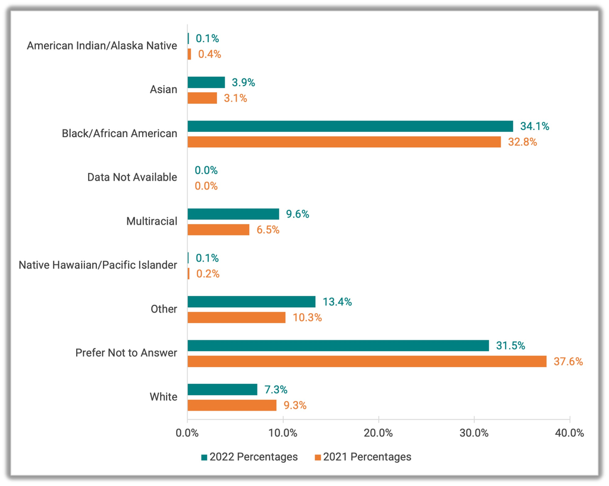

**ETHNICITY**

#### Financial Empowerment Centers

**Number of clients served with at least one financial counseling session of no fewer than 30 minutes**  
2022: 3,521  
2021: 3,244

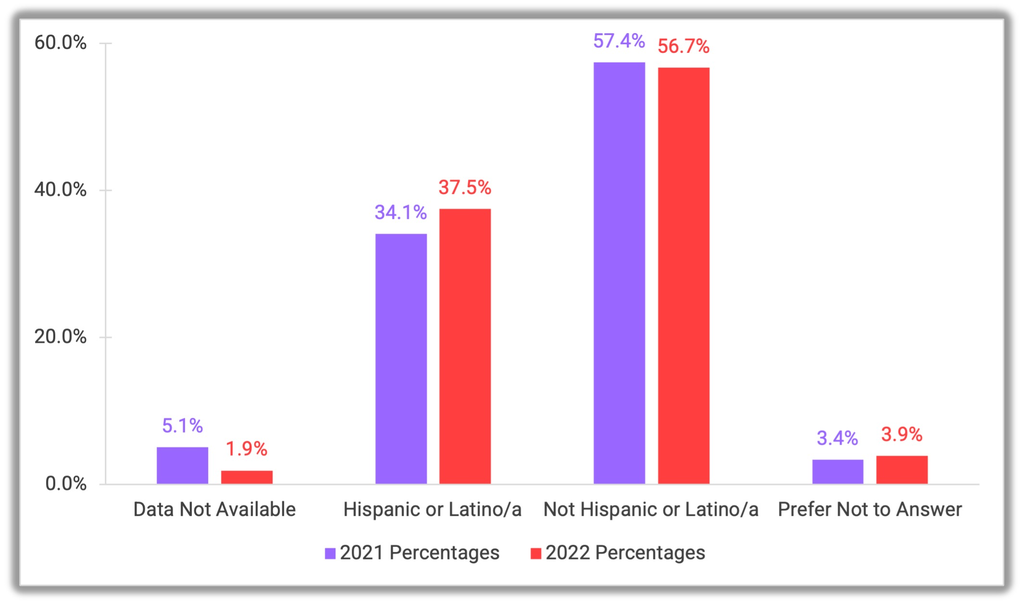

#### Free Tax Prep

**Data among filers served by contracted nonprofits who responded to survey**  
2022: 29,187  
2021: 20,606

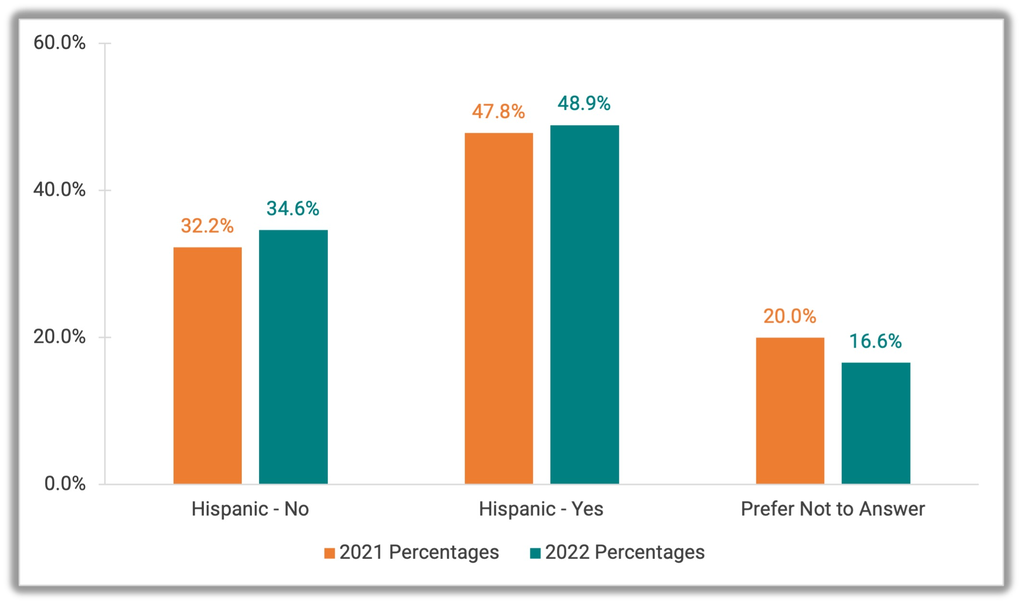

**GENDER**

#### Financial Empowerment Centers

**Number of clients served with at least one financial counseling session of no fewer than 30 minutes**  
2022: 3,521  
2021: 3,244

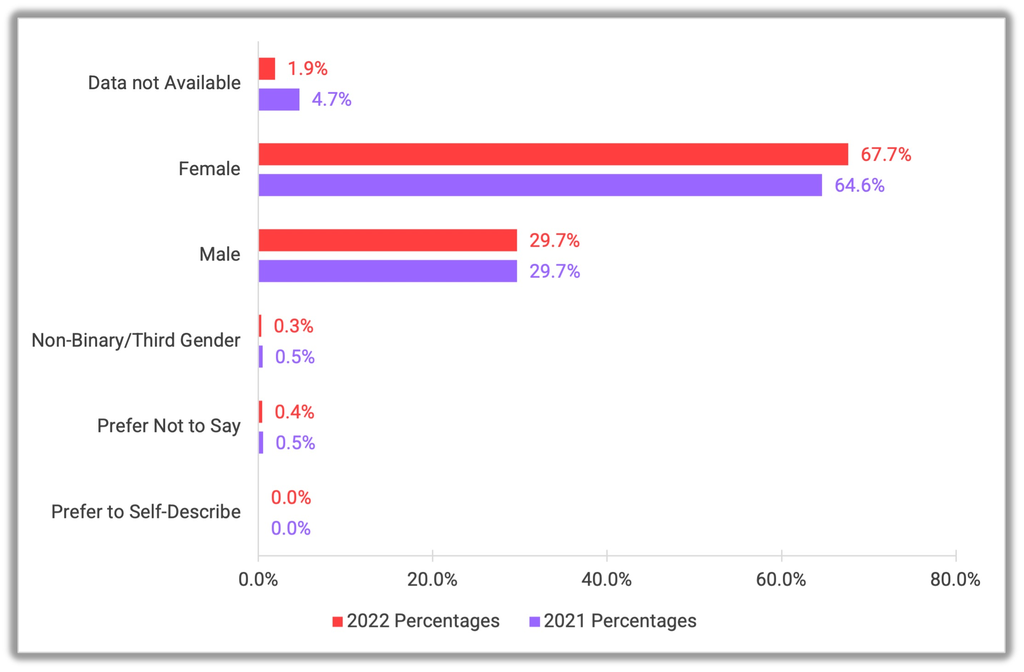

#### Free Tax Prep

**Data among filers served by contracted nonprofits who responded to survey**  
2022: 29,187  
2021: 20,606

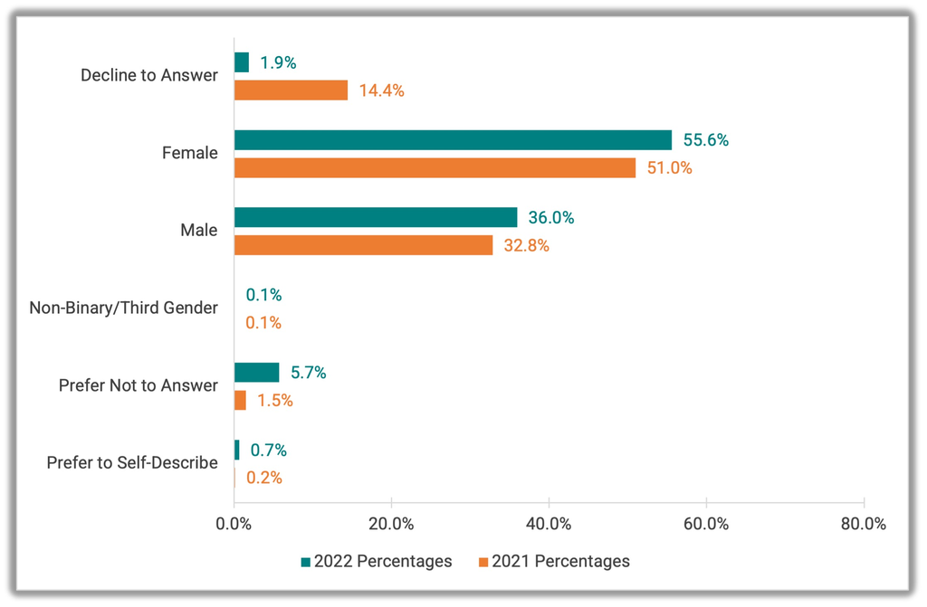

**RESIDENCE IN AT-RISK  NEIGHBORHOODS**

What is an *at-risk neighborhood**?

An at-risk neighborhood is a neighborhood with a high share of one or more of the following factors: unbanked households, residents with inadequate emergency savings, residents without access to revolving credit, and residents with debt in collections. See the *Notes* for more information.

#### Financial Empowerment Centers

**Number of clients served with at least one financial counseling session of no fewer than 30 minutes**  
2022: 3,521  
2021: 3,244

| Borough | Neighborhood | 2021 (%) | 2022 (%) |
| --- | --- | --- | --- |
| Brooklyn | Brownsville &amp; Ocean Hill | 4.5 | 3.78 |
| Brooklyn | Bushwick | 0.71 | 0.54 |
| Brooklyn | East Flatbush, Farragut &amp; Rugby | 0.89 | 0.77 |
| Brooklyn | East New York &amp; Starrett City | 3.58 | 3.38 |
| Bronx | Bedford Park, Fordham North &amp; Norwood | 3.76 | 4.83 |
| Bronx | Belmont, Crotona Park East &amp; East Tremont | 2.71 | 3.46 |
| Bronx | Castle Hill, Clason Point &amp; Parkchester | 2.87 | 3.86 |
| Bronx | Concourse, Highbridge &amp; Mount Eden | 2.74 | 2.9 |
| Bronx | Hunts Point, Longwood &amp; Melrose | 4.99 | 6.87 |
| Bronx | Morris Heights, Fordham South &amp; Mount Hope | 2.62 | 3.78 |

[output cut: 8 more lines]

#### Free Tax Prep**

**Data among filers served by contracted nonprofits who responded to survey**  
2022: 29,187  
2021: 20,606

| Borough | Neighborhood | 2021 (%) | 2022 (%) |
| --- | --- | --- | --- |
| Brooklyn | Brownsville &amp; Ocean Hill |  | 3.36 |
| Brooklyn | Bushwick |  | 0.75 |
| Brooklyn | East Flatbush, Farragut &amp; Rugby |  | 1.03 |
| Brooklyn | East New York &amp; Starrett City |  | 2.42 |
| Bronx | Bedford Park, Fordham North &amp; Norwood |  | 6.68 |
| Bronx | Belmont, Crotona Park East &amp; East Tremont |  | 3.52 |
| Bronx | Castle Hill, Clason Point &amp; Parkchester |  | 3.92 |
| Bronx | Concourse, Highbridge &amp; Mount Eden |  | 3.06 |
| Bronx | Hunts Point, Longwood &amp; Melrose |  | 6.77 |
| Bronx | Morris Heights, Fordham South &amp; Mount Hope |  | 5.36 |

[output cut: 8 more lines]

##### Notes:

* At-risk neighborhoods defined in [this OFE report](https://www1.nyc.gov/assets/dca/downloads/pdf/partners/COVID_Vulnerability_Brief.pdf).  
** Data by zip code are not available for tax year 2021.